# cleaning data

megzy

2022/5/10

## Exampe for the site SE-Nor

the data cleaning step will be based on the site SE-Nor and gpp as the example. The data is from Koen’s data set. The variable used here include the site information and the corresonding temp, prec, ppfd, vpm for the HH values. the essential packages and functions we need for the steps:

```r
rm = list(ls())
library(tidyverse)
library(ggplot2)
library(lubridate)
source("n_functions.R")
dat1 <- read_csv("dat1.csv")
```

```
## * `` -> ...1
```

```r
#why still shows the reading info
```

## 1. pre-process for data

This step include removing the NA values and also converting the data into daily for analysis.

```r
dat.1 <- table(is.na(dat1$gpp))
```

Then we can show the NAs in the data set.

```r
dat.1
```

```
##
## FALSE  TRUE
##  2546     9
```

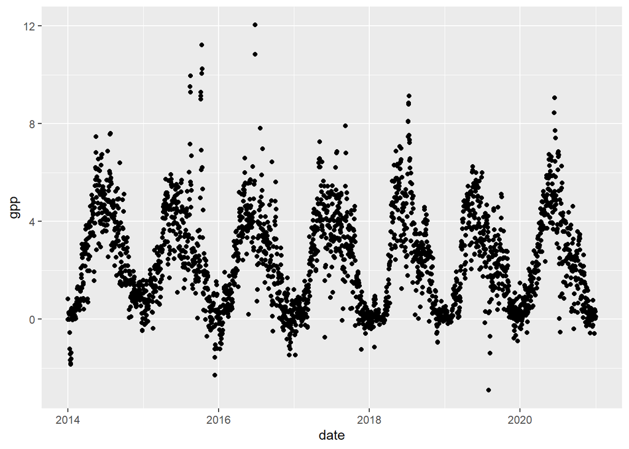

```r
ggplot(data = dat1, aes(x = date, y = gpp))+
  geom_point()
```

## 2.outliers

This step will detect the outliers. The outliers are based on the residues which is out of 3*IQR.

```r
dat2 <- add_outliers(mydata = dat1)
```

Then we can visualize the results.

```r
dat.2 <- table(dat2$outline)
dat.2
```

```
##
##   in  out
## 2437  109
```

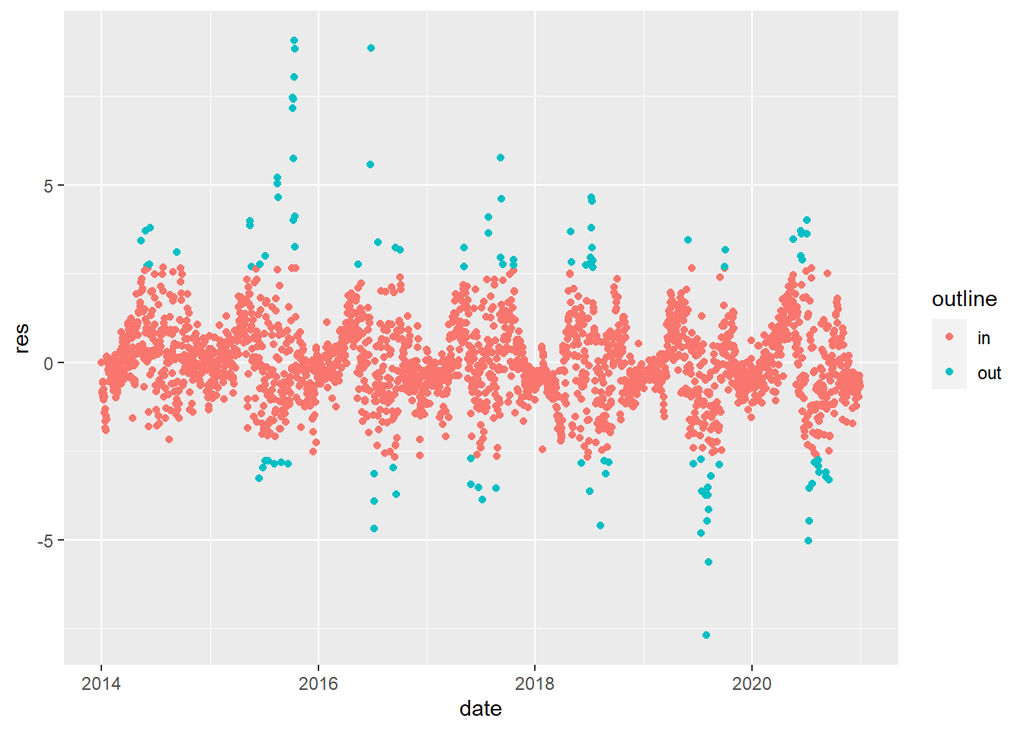

```r
ggplot(data = dat2, aes(x = date, y = res))+
  geom_point(aes(color = outline))
```

## 3.drift

This step will test if there are drifts in the gpp value. The method based on if the year effect will become a significant driver for the linear model of gpp.

```r
dat3 <- add_drift(mydata = dat2)
```

There are no drifts be detected here.

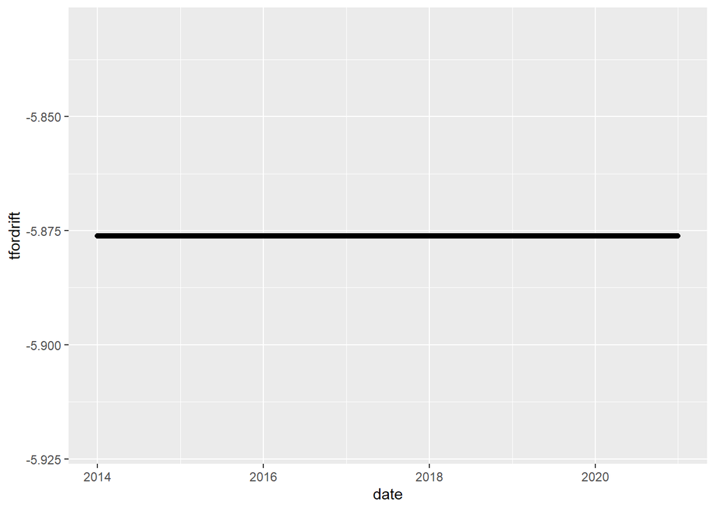

```r
ggplot(data = dat3, aes(x = date, y = tfordrift))+
  geom_point()
```

## 4.spurious value

This step is for testing if there are data having the same gpp value as others. Because of the data is double precision, so the probability for having 2 same one can be really low. That’s why we need to detect the spurious values to see if there is error for the gpp value.

```r
dat4 <- add_spurious(mydata = dat3)
```

Here are the results.

```r
dat.4 <- table(dat4$rep)
dat.4
```

```
##
##    1
## 2546
```

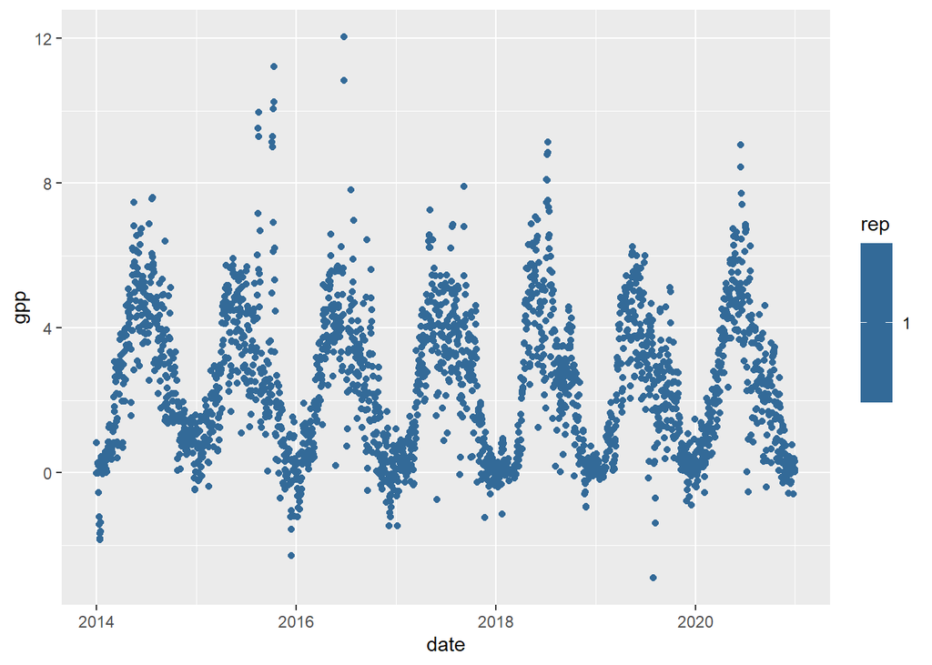

```r
ggplot(data = dat4, aes(x = date, y = gpp))+
  geom_point(aes(color = rep))
```

## 5. growing season

We use the gpp value to know if it a the growing season.

```r
dat5 <- GrowingSeason(mydata = dat4)
```

Here is the graph.

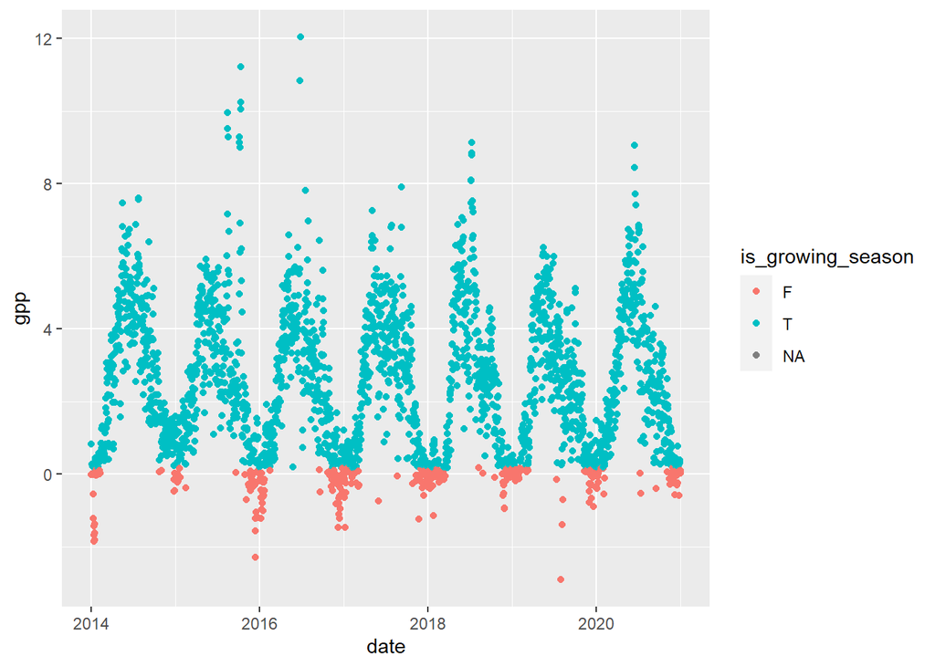

```r
ggplot(data = dat5, aes(x = date, y = gpp))+
  geom_point(aes(color = is_growing_season))
```

## 6. step change detection

When building the model, there will be some points become critical for the 2 different model, which may be an indicator for we need to building different model corresponding to time period. Here we use the method from Chow’s Test in statistics to test these step change points. The p-value is set as 0.05 here. In case of over sensitivity, the data will be treated monthly.

```r
dat6 <- add_step_change(mydata = dat5)
```

The result shows there are 13 possible step change point.

```r
#this part has error for knitting but don't know why...google doesn't work...
dat.6 <- table(dat6$SCpoint)
dat.6
```

```
##
## NON  SC
##  60  13
```

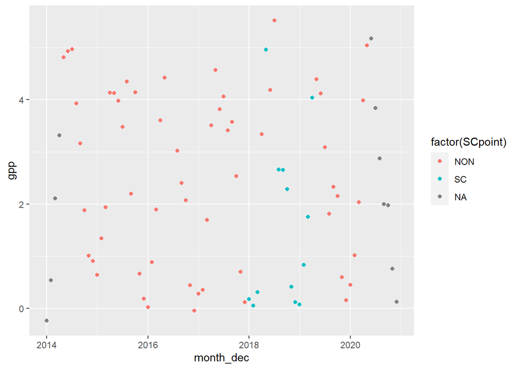

```r
ggplot(data = dat6, aes(x = month_dec, y = gpp))+geom_point(aes(color = factor(SCpoint)))
```